# Coursera / JHBSPH - Reproducible Research - Assignment 1

Raj Manickam

June 12, 2014

### Loading and preprocessing the data

```r
# Use setwd() to set working directory to directory containing this project
setwd('~/appdev/jhsph/repdata/RepData_PeerAssessment1/')
suppressPackageStartupMessages(library(ggplot2))
suppressPackageStartupMessages(library(dplyr))
suppressPackageStartupMessages(library(data.table))
suppressPackageStartupMessages(library(lubridate))
suppressPackageStartupMessages(library(stringr))
# suppressPackageStartupMessages(library(Hmisc))

try(system('unzip -o activity.zip'))
activity = data.table(read.csv(file = 'activity.csv'))
try(system('rm activity.csv'))

activity$obsTime =
        str_pad( activity$interval, 4, side = 'left', pad = '0')

# Get summary by time of day
activityByInterval = activity %.%
    group_by(obsTime) %.%
    summarize(stepsMean = mean(steps, na.rm = TRUE))

activityByInterval$MinutesFromMidnight =   as.integer( substring(
                                    activityByInterval$obsTime, 1, 2 ) ) * 60 +
                                as.integer( substring(
                                    activityByInterval$obsTime, 3, 4 ) )

# Generate summary by date
activityByDate = activity %.%
    group_by(date) %.%
    summarize(stepsSum = sum(steps))
```

### What is mean and median number of steps taken per day?

```r
stepsDailyMean = mean(activityByDate$stepsSum, na.rm = TRUE)
stepsDailyMedian = quantile(activityByDate$stepsSum, probs = c(0.5), na.rm = TRUE)
```

The mean number of steps taken daily during this period is 1.0766 × 10<sup>4</sup>. The median number of steps taken daily during this period is 1.0765 × 10<sup>4</sup>.

### Make a histogram of the total number of steps taken each day

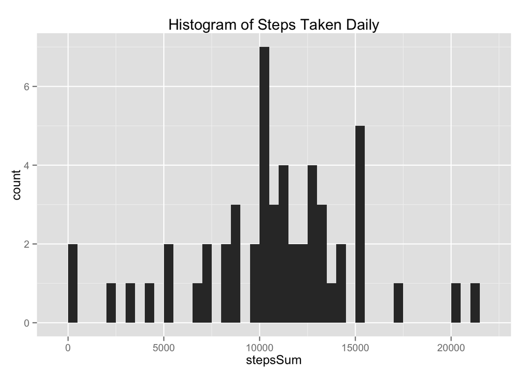

```r
plot1 = ggplot( data = activityByDate,
        aes( x = stepsSum)) +
        geom_histogram( stat = 'bin', binwidth = 500) +
        ggtitle( 'Histogram of Steps Taken Daily')
ggsave(file.path('figures', 'plot1.pdf'))
plot1
```

### What is the average daily activity pattern?

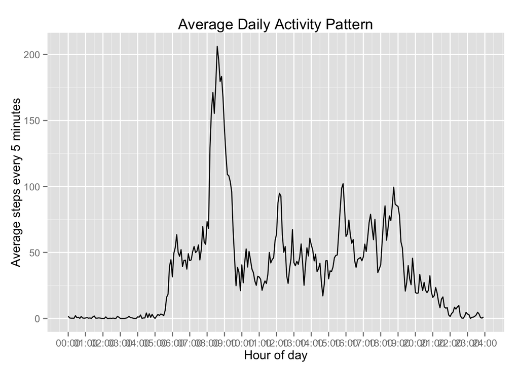

```r
# Make a time series plot (i.e. type = "l") of the 5-minute interval (x-axis)
# and the average number of steps taken, averaged across all days (y-axis)
plot2 = ggplot( activityByInterval, aes( x = MinutesFromMidnight ) ) +
    geom_line( aes( y = stepsMean ) ) +
    scale_x_continuous( breaks = seq( 0, 1440, 60 ),
        labels = c( '00:00', '01:00', '02:00', '03:00', '04:00', '05:00', '06:00',
                    '07:00', '08:00', '09:00', '10:00', '11:00', '12:00', '13:00',
                    '14:00', '15:00', '16:00', '17:00', '18:00', '19:00', '20:00',
                    '21:00', '22:00', '23:00', '24:00' ) ) +
    ggtitle( 'Average Daily Activity Pattern' ) +
    xlab( 'Hour of day' ) +
    ylab( 'Average steps every 5 minutes' )
ggsave(file.path('figures', 'plot2.pdf'))
plot2
```

### Which 5-minute interval, on average across all the days in the dataset, contains the maximum number of steps?

The 5-minute interval in which the the most steps were logged, on average, across all the days in the dataset, is 0835.

### Imputing missing values

Calculate and report the total number of missing values in the dataset (i.e. the total number of rows with NAs)

```r
missingObs = sum(!complete.cases(activity$steps))
```

There are 2304 observations which have some missing variable ‘steps’, out of a total of 17568 rows (13.1148%).

Strategy for filling in all of the missing values in the dataset: Will use mean for that 5-minute interval from all days in the dataset. If all the values for a certain interval is NA, then use 0.

```r
# Create a new dataset that is equal to the original dataset but with the missing data filled in.
activityTidy = activity
# Get the vector of rows with missing steps
stepsNA = activityTidy$obsTime[ is.na( activityTidy$steps ) ]
# Get corresponding row of obsTime in activityByInterval
rowIndex = sapply( stepsNA, function( x ) which( activityByInterval$obsTime == x ) )
# Replace NA values with corresponding values
activityTidy$steps[ is.na( activityTidy$steps ) ] = activityByInterval$stepsMean[ rowIndex ]
```

### Make a histogram of the total number of steps taken each day and Calculate and report the mean and median total number of steps taken per day.

Do these values differ from the estimates from the first part of the assignment? What is the impact of imputing missing data on the estimates of the total daily number of steps?

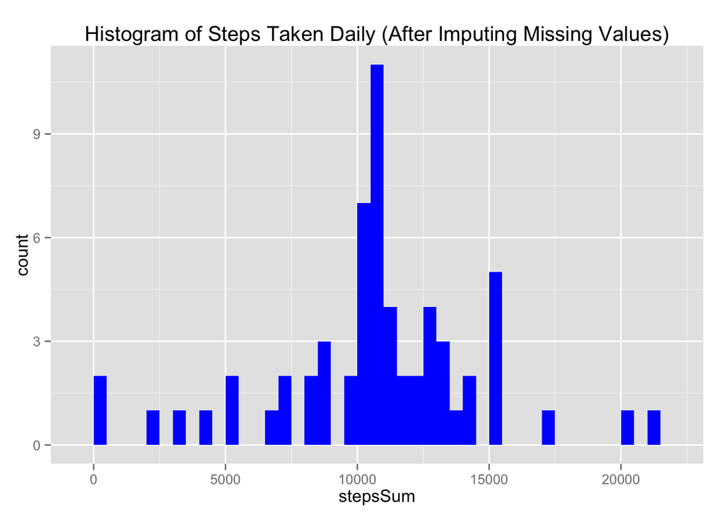

```r
activityTidyByDate = activityTidy %.%
    group_by(date) %.%
        summarize(stepsSum = sum(steps))

stepsDailyMeanTidy = mean(activityTidyByDate$stepsSum, na.rm = TRUE)
stepsDailyMedianTidy = quantile(activityTidyByDate$stepsSum, probs = c(0.5), na.rm = TRUE)

# plot3 = ggplot() +
#     geom_histogram( data = activityByDate,
#                     aes( x = stepsSum),
#                     stat = 'bin',
#                     binwidth = 500,
#                     fill = 'red' ) +
#         ggtitle( 'Histogram of Steps Taken Daily (Before Imputing Missing Values)')
# ggsave(file.path('figures', 'plot3.pdf'))

plot4 = ggplot() +
    geom_histogram( data = activityTidyByDate,
                    aes( x = stepsSum),
                    stat = 'bin',
                    binwidth = 500,
                    fill = 'blue' ) +
        ggtitle( 'Histogram of Steps Taken Daily (After Imputing Missing Values)')
ggsave(file.path('figures', 'plot4.pdf'))
# plot3
plot4
```

The mean number of steps taken daily during this period is 1.0766 × 10<sup>4</sup>. The median number of steps taken daily during this period is 1.0766 × 10<sup>4</sup>.

The mean number of steps did not change after imputing missing values (as they were imputed based on the mean values). The median number of steps increased slightly.

### Are there differences in activity patterns between weekdays and weekends?

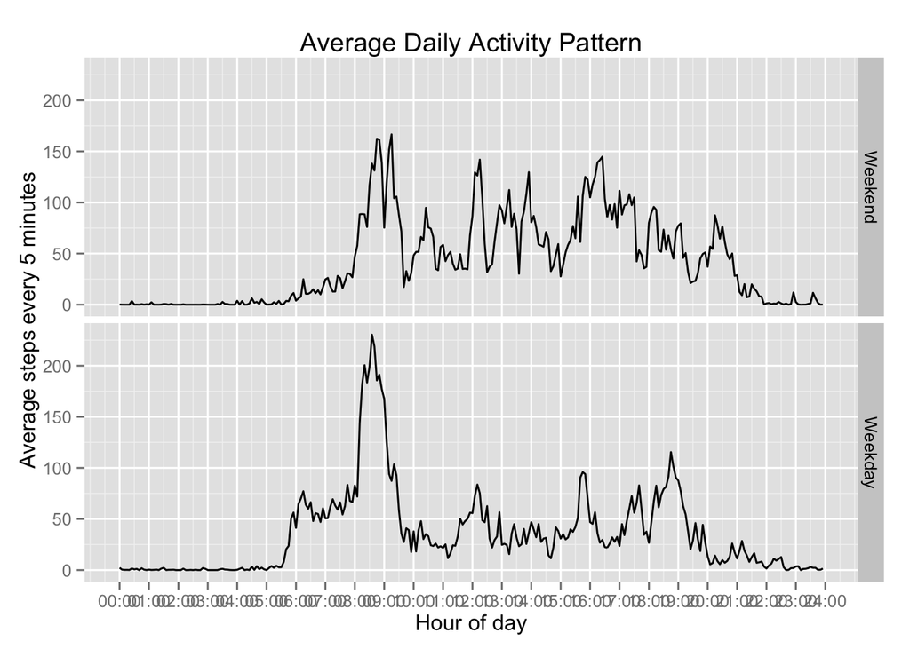

```r
activityTidy$weekday = factor( weekdays( ymd( activityTidy$date)) %in%
            c( 'Monday','Tuesday','Wednesday','Thursday','Friday'), labels = c('Weekend', 'Weekday'))

# Get summary by time of day and Weekend/Weekday
activityTidyByDateByInterval = activityTidy %.%
    group_by(weekday, obsTime) %.%
    summarize(stepsMean = mean(steps, na.rm = TRUE))

activityTidyByDateByInterval$MinutesFromMidnight =   as.integer( substring(
                                    activityTidyByDateByInterval$obsTime, 1, 2 ) ) * 60 +
                                as.integer( substring(
                                    activityTidyByDateByInterval$obsTime, 3, 4 ) )

plot5 = ggplot( activityTidyByDateByInterval, aes( x = MinutesFromMidnight ) ) +
    geom_line( aes( y = stepsMean ) ) +
    scale_x_continuous( breaks = seq( 0, 1440, 60 ),
        labels = c( '00:00', '01:00', '02:00', '03:00', '04:00', '05:00', '06:00',
                    '07:00', '08:00', '09:00', '10:00', '11:00', '12:00', '13:00',
                    '14:00', '15:00', '16:00', '17:00', '18:00', '19:00', '20:00',
                    '21:00', '22:00', '23:00', '24:00' ) ) +
    ggtitle( 'Average Daily Activity Pattern' ) +
    xlab( 'Hour of day' ) +
    ylab( 'Average steps every 5 minutes' ) +
    facet_grid( weekday ~ . )
ggsave(file.path('figures', 'plot5.pdf'))
plot5
```

There is a distinct shift in pattern of activity over the weekend, compared to the weekdays. The person starts being ‘Active’ about two hours later (sleeps in late?), and is more active in the afternoon and evening.